# Pregunta 06

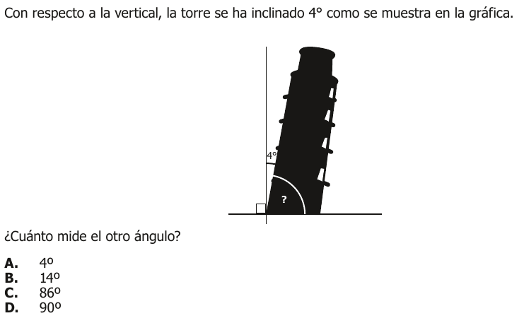

### Análisis

Identificamos los elementos clave del problema:

- Una torre que se ha inclinado 4° respecto a la vertical
- Un ángulo desconocido (marcado con ?)
- Una línea horizontal (base)
- Una línea vertical (referencia)

## Desarrollo Conceptual

1. **Principio de Ángulos Rectos**
   - En una línea vertical con respecto a una horizontal, se forma un ángulo de $90^\circ$
   - Esto se expresa matemáticamente como: $90^\circ$
2. **Propiedades de Ángulos Complementarios**
   - En una línea vertical, cuando se inclina, se forman dos ángulos complementarios
   - La suma de estos ángulos debe ser igual a $90^\circ$
   - Matemáticamente: $\alpha + \beta = 90^\circ$ donde:
   - $\alpha$ = ángulo de inclinación ($4^\circ$)
   - $\beta$ = ángulo desconocido (?)

## Resolución Paso a Paso

1. Aplicamos la ecuación de ángulos complementarios: $4^\circ + \beta = 90^\circ$
2. Despejamos el ángulo desconocido: $\beta = 90^\circ - 4^\circ$ $\beta = 86^\circ$
3. Verificamos en las opciones dadas:
   - A. $4^\circ$ (Incorrecto)
   - B. $14^\circ$ (Incorrecto)
   - C. $86^\circ$ (Correcto)
   - D. $90^\circ$ (Incorrecto)

## Conclusión

La respuesta correcta es la opción **C. $86^\circ$**

## Verificación

- El resultado es coherente porque:
  - Cumple con el principio de ángulos complementarios
  - $4^\circ + 86^\circ = 90^\circ$
  - Representa el ángulo mayor observado en la figura
  - Satisface las leyes de la geometría euclidiana

## Nota Pedagógica

Este problema ilustra la importancia de:

- El concepto de perpendicularidad
- Las propiedades de ángulos complementarios
- La relación entre la vertical y la inclinación

### Análisis de la Pregunta 2023-Matematicas-11-1-06, según SABER 11 ICFES

- Nivel de Desempeño: 2
- Competencia: Interpretación y Representación
  - Afirmación: Comprende y transforma la información cuantitativa y esquemática presentada en distintos formatos
  - Evidencia: Da cuenta de las características básicas de la información presentada en diferentes formatos
- Componente: Geométrico-Métrico
- Estándar Asociado: Uso argumentos geométricos para resolver y formular problemas en contextos matemáticos y en otras ciencias
- ¿Qué evalúa?: La capacidad para identificar y calcular ángulos complementarios en una situación geométrica contextualizada
- Respuesta Correcta: C. 86°
  - Justificación: Al ser ángulos complementarios, suman 90°. Si uno mide 4°, el otro debe medir 86° (90° - 4° = 86°)
- Motivos de las opciones incorrectas:
  - A (4°): Confunde el ángulo dado con el ángulo pedido
  - B (14°): No comprende el concepto de ángulos complementarios
  - D (90°): Confunde el ángulo recto total con el ángulo pedido
- Contenidos Matemáticos Curriculares:
  - Geometría
  - Período 1
    - Geometría Básica del Triángulo, Rectas y Ángulos
      - Teoría del ángulo
- Tipo: Genérico
- Eje Axial Disciplinar: Complementarios, Suplementarios y Operaciones Proporcionales
- Tarea: Determinar la medida de un ángulo complementario conociendo uno de los ángulos
- Grado: 8° - 11°